# Assignment 3

Benjamin Tudor Price | TUDORPR1

2023-04-09

```r
if (!requireNamespace("BiocManager"))
    install.packages("BiocManager", quietly=TRUE)

if (!requireNamespace("GSA"))
    install.packages("GSA", quietly=TRUE)

if (!requireNamespace("biomaRt"))
    install.packages("biomaRt", quietly=TRUE)

if (!requireNamespace("ComplexHeatmap"))
    BiocManager::install("ComplexHeatmap", quietly=TRUE)

if (!requireNamespace("org.At.tair.db"))
  BiocManager::install("org.At.tair.db", quietly=TRUE)
```

## Non-thresholded Gene set enrichment analysis

1. I used GSEA V-4.3.2 to test my ranked genes for enrichment to the GO Biological Process, GO Molecular Function and GO Cellular Component databases (BioMart releases/2022-12-04) (Consortium, 2004; Smedley *et al.*, 2009; Subramanian *et al.*, 2007).
2. Overall, the results were similar to previous analyses, but found far annotations were found with links to growth. In the light condition, annotations involved with high energy processes, such as peptide synthesis and mitosis. We also see significant enrichment for genes involved with photosynthesis and chloroplast development. In the dark condition, we see enrichment for annotations involved with induction of elongation (response to ethlene), response to low oxygen levels, and vacuolar transporation networks. All of these terms make perfect sense given our phenotype.
3. These results are in agreement with the previous analyses at a high level, but were able to detect enrichment for DE of high energy metabolic procceses far more effectively. In general, comparison of these results is fairly straight forward if we assume that the adjusted p-values provide comparable accuracy, but this is slightly complicated by the fact that there are many interrelated GO terms. So even if the GO matches found by each method are slightly different, they could well be saying the same thing.

## Cytoscape Visualisation of GSEA

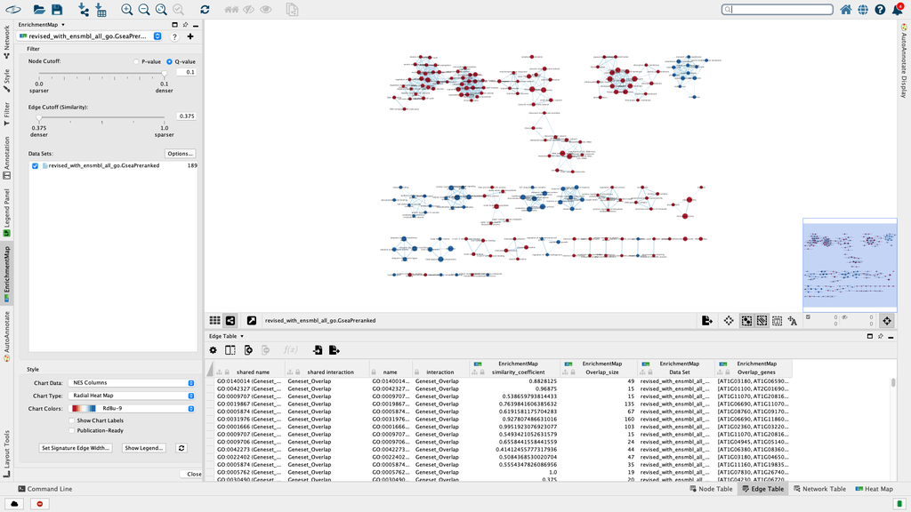

```r
knitr::include_graphics(file.path(getwd(), 'figs', "initial_ss.png"))
```

2. See below.

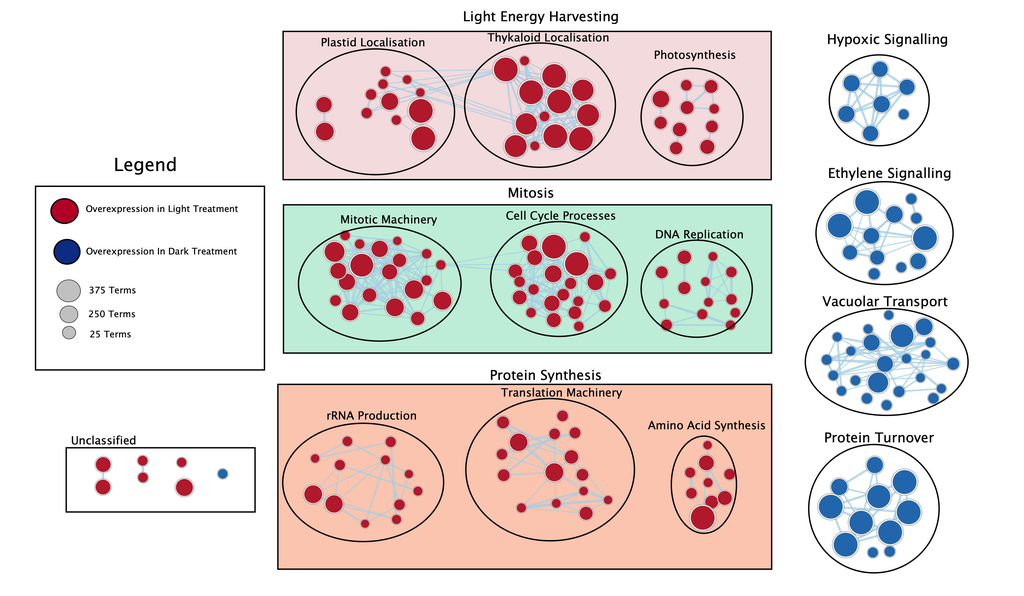

```r
knitr::include_graphics(file.path(getwd(), 'figs', "go_all.png"))
```

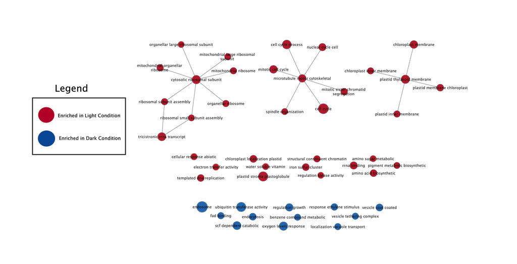

```r
knitr::include_graphics(file.path(getwd(), 'figs', "collapsed.png"))
```

## Interpretation and detailed view of results

1. Yes. These patterns of genes expression are exactly what we would expect from Arabidopsis exposed to light and dark conditions, and contain a micture of organ specific signals, as reported by the original authors (Martı́n & Duque, 2021). In light conditions, Arabidopsis invests its energy into the further development of its photosynthetic capacity. This can be seen in the far higher expression of chloroplast components, as reported above. The energy produced by this photosynthetic capacity allows for further cell division and free production of proteins. In the dark condition, Arabidopsis rapidly elongates, investing little in its photosynthetic capacity and relying on energy stored in its seed. A potential alaysis of the observed respose is as follows: hypoxic signalling is indicative of reduced energy consumption, ethylene signalling is indicative of increased elongation, vaculor transport is indicative of increased nutrient transit (from the seed to the rest of the plant), and increased protein turnover is a symptom of less energy being available to synthesize amino acids.
2. Some of above insights are well documented in the literature (Alabadı́ *et al.*, 2008; Ecker, 1995; Ishihara *et al.*, 2017; Kim & Arnim, 2006). Ribosome production and protein synthesis require significant energy input. When energy is abundant and the organism is rapidly growing, peptide and ribosome synthesis occurs at a high rate. When energy is less abundant, protein turnover become relatively more active.

## Setup for Dark Matter Analyses

```r
library(org.At.tair.db)
```

```r
library(readr)
library(GSA)

map <- org.At.tair.db::org.At.tairSYMBOL
mapped_tairs <- AnnotationDbi::mappedkeys(map)
map <- as.list(map[mapped_tairs])
chr_map <- lapply(map, paste, collapse=' ')


# Parse ranks file.
locus_ranks_path <- file.path(getwd(), 'data', "locus_rank_list.rnk")
ranks <- read.csv(locus_ranks_path, sep='\t', header=FALSE)
names(ranks) <- c("Locus", "Rank")

# Parse GMT file
gmt_path <- file.path(getwd(), 'data',  "ENSEMBL_GOALL.gmt")
capture.output(genesets<- GSA.read.gmt(gmt_path),file="data/gsa_load.out")
names(genesets$genesets) <- genesets$geneset.names

# Parse raw DE data.
output_hits <- read.csv(file.path(getwd(), 'data', "output_hits.csv"))
sel <- is.na(output_hits$NAME)
output_hits$NAME[sel] <- output_hits$ID[sel]

# Find included genes.
iter <- 0
every <- 100
unique_genes <- character()

unique_genes <- unique(unlist(genesets$genesets))

all_names <- function(locus_id){
  if (locus_id %in% names(chr_map)){
    return(c(locus_id, unlist(strsplit(chr_map[[locus_id]], split=' +'))))
  } else {
    return(locus_id)
  }
}

any_names_in <- function(locus_ids, gene_collection){
  rtrn <- logical(length(locus_ids))
  for (i in seq_along(locus_ids)){
    locus_id <- locus_ids[i]
    ids <- all_names(locus_id)

    if (any(ids %in% gene_collection)){
      rtrn[i] <- TRUE
    }
  }
  return(rtrn)
}

# Parse Counts Data
norm_cpms <- read.table(file=file.path(getwd(), 'data', "normalized_cpms.csv"),
                        header = TRUE,sep = ",",
                        stringsAsFactors = FALSE,
                        check.names=FALSE)
norm_cpms <- cbind(norm_cpms[, 1:2], norm_cpms[grep('WT', names(norm_cpms))])

gene_heatmap <- function(loci_ids){
  mi_inds <- match(loci_ids, norm_cpms$ID)
  # gene_names <- output_hits$NAME[match(loci_ids, output_hits$ID)]

  # Convert our normalized cpms into matrix visulisable on heatmap.
  heatmap_matrix <- norm_cpms[mi_inds,3:ncol(norm_cpms)]
  colnames(heatmap_matrix) <- colnames(norm_cpms[mi_inds,3:ncol(norm_cpms)])
  rownames(heatmap_matrix) <- loci_ids

  # Scale heatmap with row normalisation
  heatmap_matrix <- t(scale(t(heatmap_matrix)))
  nans <- which(is.nan(heatmap_matrix[,1]))
  heatmap_matrix[nans, ] <- 0

  # Select colour scheme - add additional colour if negative values present.
  if(min(heatmap_matrix) == 0){
    heatmap_col = circlize::colorRamp2(c( 0, max(heatmap_matrix)),
                             c( "white", "red"))
  } else {
    heatmap_col = circlize::colorRamp2(c(min(heatmap_matrix), 0,
          max(heatmap_matrix)), c("blue", "white", "red"))
  }


  current_heatmap <- ComplexHeatmap::Heatmap(as.matrix(heatmap_matrix),
        show_row_dend = FALSE, show_column_dend = TRUE,
        col=heatmap_col,show_column_names = TRUE,
        show_heatmap_legend = TRUE, use_raster=TRUE,
        heatmap_legend_param = list(title = 'Relative CPM'))

  return(current_heatmap)
}
```

## Finding Genes Not Included in Any GO Terms

```r
reg_p_val_th <- 0.000005

output_hits$included <- any_names_in(output_hits$ID, unique_genes)
output_hits$rank <- -log(output_hits$adj.P.Val, base = 10) * sign(output_hits$logFC)


not_incl <- output_hits$ID[! output_hits$included & output_hits$adj.P.Val < reg_p_val_th]
length(not_incl)
```

```
## [1] 7
```

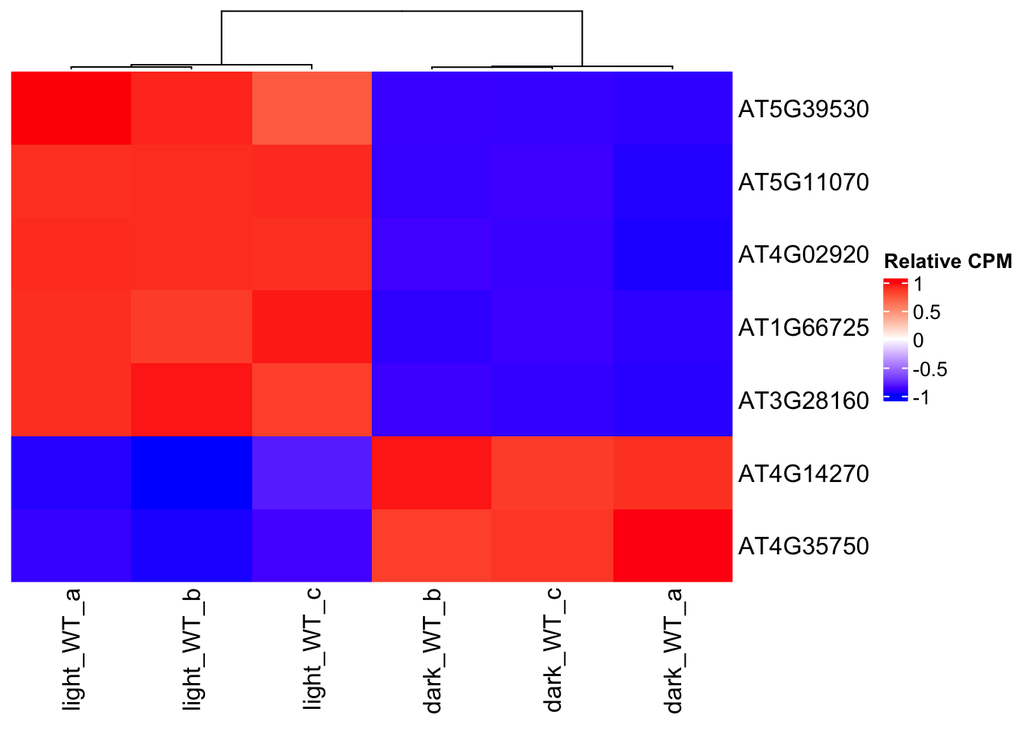

```r
dmdf <- data.frame(id=not_incl,
                   symbol=output_hits$NAME[match(not_incl, output_hits$ID)],
                   p_val=output_hits$adj.P.Val[match(not_incl, output_hits$ID)])
ni_dmdf <- dmdf[order(dmdf$p_val),]
gene_heatmap(not_incl)
```

Figure 4. A heatmap showing the relative expression levels of genes with and adjusted p value < 5^{-6}, but without any annotation among all annotations used for GSEA. Annotations include GO Biological Process, GO Molecular Funciton, and GO Cellular Component (excluding electronic annotaions).

## Finding Dark Matter in Up Regulated Genes.

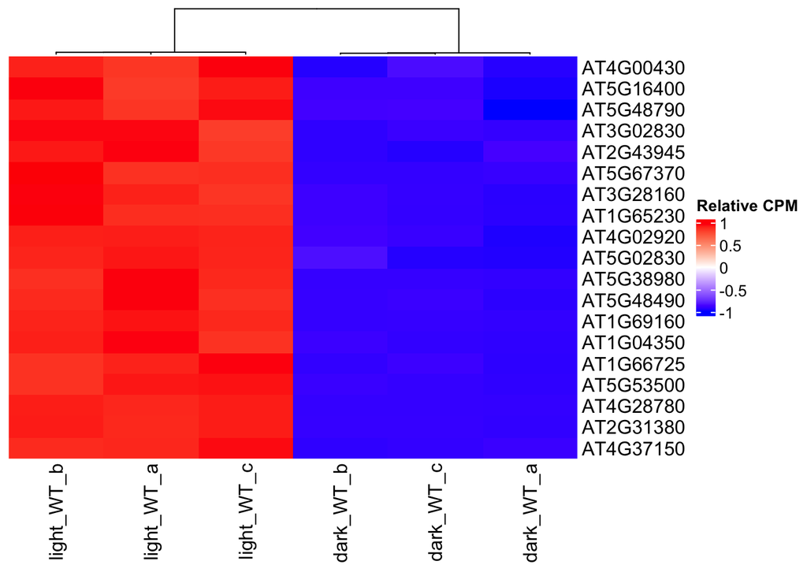

```r
go_p_val_thr <- 0.05
up_reg_p_val_th <- 0.000002

nt <- function(x){return(- log(x, base=10))}

# Get up regulated genes inlcuded in go terms.
up_reg <- read.csv(file.path(getwd(), 'data', "gsea_up_reg.tsv"), sep='\t')
up_reg_go_terms <- up_reg$GS.br..follow.link.to.MSigDB[up_reg$NOM.p.val < go_p_val_thr]
accounted_for <- genesets$genesets[up_reg_go_terms]
accounted_for <- unique(unlist(accounted_for))

# Get up regulated gene not included in go terms.
up_reg <- ranks$Locus[ranks$Rank > nt(up_reg_p_val_th)]
dark_matter <- up_reg[! any_names_in(up_reg, accounted_for)]

dmdf <- data.frame(id=dark_matter,
                   symbol=output_hits$NAME[match(dark_matter, output_hits$ID)],
                   p_val=output_hits$adj.P.Val[match(dark_matter, output_hits$ID)])
up_dmdf <- dmdf[order(dmdf$p_val),]
gene_heatmap(dark_matter)
```

## Finding Dark Matter in Down Regulated Genes.

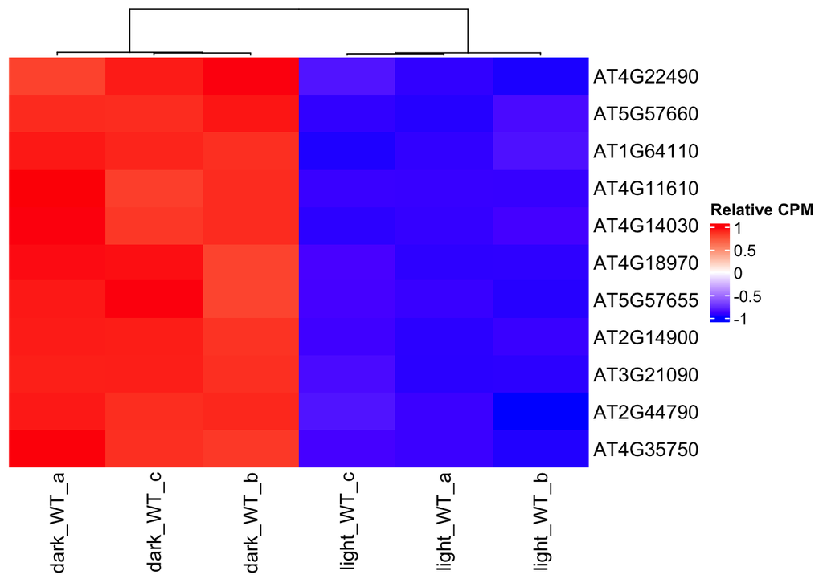

```r
go_p_val_thr <- 0.05
down_reg_p_val_th <- 0.000002

# Get down regulated genes inlcuded in go terms.
down_reg <- read.csv(file.path(getwd(), 'data', "gsea_down_reg.tsv"), sep='\t')
down_reg_go_terms <- down_reg$GS.br..follow.link.to.MSigDB[down_reg$NOM.p.val < go_p_val_thr]
accounted_for <- genesets$genesets[down_reg_go_terms]
accounted_for <- unique(unlist(accounted_for))

# Get down regulated gene not included in go terms.
down_reg <- ranks$Locus[ranks$Rank < - nt(down_reg_p_val_th)]
dark_matter <- down_reg[! any_names_in(down_reg, accounted_for)]

dmdf <- data.frame(id=dark_matter,
                   symbol=output_hits$NAME[match(dark_matter, output_hits$ID)],
                   p_val=output_hits$adj.P.Val[match(dark_matter, output_hits$ID)])
down_dmdf <- dmdf[order(dmdf$p_val),]
gene_heatmap(dark_matter)
```

## References

Alabadı́ D., Gallego-Bartolomé J., Orlando L., Garcı́a-Cárcel L., Rubio V., Martı́nez C., Frigerio M., Iglesias-Pedraz J.M., Espinosa A., Deng X.W. & others (2008). Gibberellins modulate light signaling pathways to prevent arabidopsis seedling de-etiolation in darkness. The Plant Journal 53 (2): 324–335.

Consortium G.O. (2004). The Gene Ontology (GO) database and informatics resource. Nucleic Acids Research 32 (suppl_1): D258–D261. https://doi.org/10.1093/nar/gkh036.

Ecker J.R. (1995). The ethylene signal transduction pathway in plants. Science 268 (5211): 667–675.

Ishihara H., Moraes T.A., Pyl E.-T., Schulze W.X., Obata T., Scheffel A., Fernie A.R., Sulpice R. & Stitt M. (2017). Growth rate correlates negatively with protein turnover in arabidopsis accessions. The Plant Journal 91 (3): 416–429.

Kim B.-H. & Arnim A.G. von (2006). The early dark-response in arabidopsis thaliana revealed by cDNA microarray analysis. Plant molecular biology 60: 321–342.

Kucera M., Isserlin R., Arkhangorodsky A. & Bader G.D. (2016). AutoAnnotate: A cytoscape app for summarizing networks with semantic annotations. F1000Research 5 (1717): 1717.

Martı́n G. & Duque P. (2021). Tailoring photomorphogenic markers to organ growth dynamics. Plant Physiology 186 (1): 239–249.

Smedley D., Haider S., Ballester B., Holland R., London D., Thorisson G. & Kasprzyk A. (2009). BioMart–biological queries made easy. BMC genomics 10 (1): 1–12.

Subramanian A., Kuehn H., Gould J., Tamayo P. & Mesirov J.P. (2007). GSEA-p: A desktop application for gene set enrichment analysis. Bioinformatics 23 (23): 3251–3253.